# activity_log

## 課題2

### 1. `auth` モジュールの実装

- **目的**: 認証サーバーとバックエンドサーバーを分離し、バックエンドではトークンの検証のみを行う設計にする。
- **実施内容**:
  - バックエンドで必要な認証処理を行うミドルウェアを作成。
    - 過去に JWT 認証で使用したエンティティ (`Token`, `Claims`) とインターフェース (`TokenService`) を `internal/auth/*` に再利用。
    - ミドルウェア `internal/auth/echomiddleware.go` をDigest認証に合わせて微修正。

### 2. `iam` モジュールの実装

- **目的**: Digest 認証では完全なステートレス化が難しく、認証とログインの分離が困難であるため、認証関連の処理を `iam` (Identity and Access Management) モジュールとして分離。
- **実施内容**:
  - `internal/iam/digest.go` で初期の nonce 発行 (`Init`) とトークンのパース (`Parse`) を行う `Digest` 構造体を開発。
  - 以下のインターフェースを定義:
    - アカウント情報を取得する `AccountRepo`。
    - リプレイ攻撃防止のための nonce カウント (`Nc`) を管理・検証する `DigestNcRepo`。
    - nonce の生成と改ざん防止のための検証を行う `NonceService`。
    - クライアントからの Digest レスポンスを検証する `DigestTokenValidator`。
  - 具体的なサービスを実装:
    - MD5 を用いてトークンを検証する `MD5DigestValidator` (`internal/iam/validator.go`)。
    - nonce カウント (`Nc`) をメモリ上で管理する `InMemoryDigestNcRepo` (`internal/iam/inmemory.go`)。
    - HMAC を用いて nonce を生成・検証する `HMACNonceService` (`internal/iam/nonceservice.go`)。
    - アカウント情報を取得する `InMemoryAccountRepo` (`internal/iam/inmemory.go`)。
  - Digest 認証のチャレンジとレスポンスの流れを処理するミドルウェア `EchoDigestMiddleware` を実装 (`internal/iam/echodigestmiddleware.go`)。

### 3. `apiserver` モジュールの実装

- **目的**: API サーバーを設定し、依存性の注入とルートの登録を行う。
- **実施内容**:
  - `internal/apiserver/echo.go` にて:
    - Echo サーバーの初期化。
    - CORS 設定の構成。
    - `iam` の各コンポーネント（アカウントリポジトリ、nonce サービス、バリデータなど）の依存性注入を設定。
    - ミドルウェアチェーンに `iam.EchoDigestMiddleware` と `auth.EchoMiddleware` を追加。
    - ルート（例：`/secret` エンドポイント）の登録。
    - サーバーの起動。

### 4. アーキテクチャの概要

- 全体のアーキテクチャは以下のように視覚化できます:

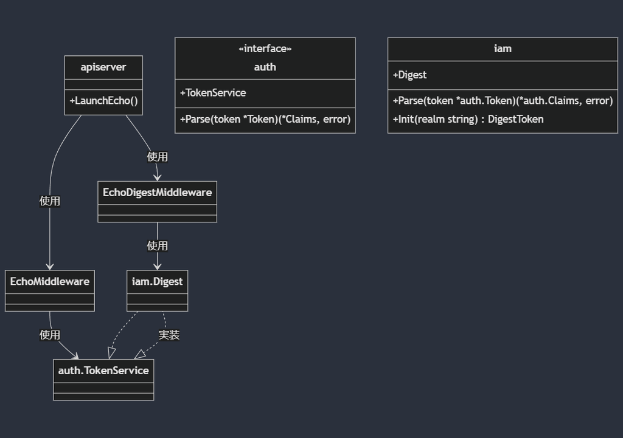

### 5. リクエストのフロー

- HTTP リクエストがミドルウェアを通過する流れは以下のとおりです:

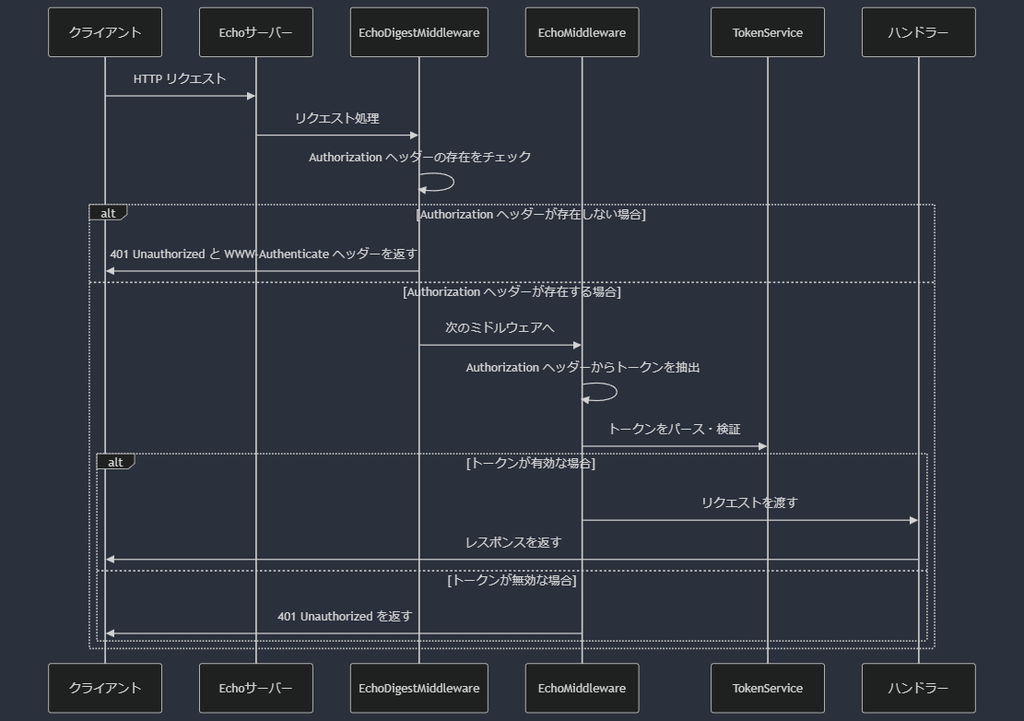

- **説明**:
  - クライアントがリクエストを行うと、`EchoDigestMiddleware` は `Authorization` ヘッダーをチェックします。
  - ヘッダーがない場合、`iam.Digest` を使用して Digest チャレンジを生成し、`401 Unauthorized` と `WWW-Authenticate` ヘッダーを返します。
  - ヘッダーがある場合、次のミドルウェアである `EchoMiddleware` へ処理が渡され、トークンの検証が行われます。
  - 最終的に、認証が成功すればリクエストはハンドラーに到達し、レスポンスがクライアントに返されます。